# Introduction to brms

Last updated: 2020-02-21

## Introduction

- `brms` = Bayesian Regression Models using Stan
- Created by [Paul-Christian Bürkner](https://github.com/paul-buerkner/brms)
- An interface to the [Stan](https://mc-stan.org/) probabilistic programming language + sampling routines
- Allows fitting of a huge range of models using `R`'s formula syntax
- These slides aim to introduce the main functions

## R formula syntax

| term | meaning |
| --- | --- |
| `y ~ 1 + x` | `y` predicted by `x` (1 = intercept, included by default) |
| `y ~ 1 + x + z + x:z` | two variables and interaction (equivalent to `y ~ x*z`) |
| `(1 \| g)` | allow the intercept to vary by levels of `g` |
| `(1 + x \| g)` | allow intercept and slope to vary and model correlation between these 'random effects' |
| `(0 + x \| g)` | fixed intercept, random slope |
| `(1 + x \|\| g)` | model random effects but not correlation (fix \(\rho\) to 0) |

## `brm()`

```r
brm(formula, data, family = gaussian(), prior = NULL,
  sample_prior = c("no", "yes", "only"),
  chains = 4, iter = 2000, warmup = floor(iter/2),
  thin = 1, cores = getOption("mc.cores", 1L))
```

see `?brm` for more

- We'll work through an example with the `sleepstudy` data set from `lme4` (in `examples/sleepstudy.csv`)
- Example code in `examples/brms-example1.R`

## sleepstudy

Data from a sleep deprivation study

Reaction times for 18 participants following 0-9 Days of sleep deprivation

```r
head(sleepstudy)
```

```
##   Reaction Days Subject
## 1 249.5600    0     308
## 2 258.7047    1     308
## 3 250.8006    2     308
## 4 321.4398    3     308
## 5 356.8519    4     308
## 6 414.6901    5     308
```

## sleepstudy

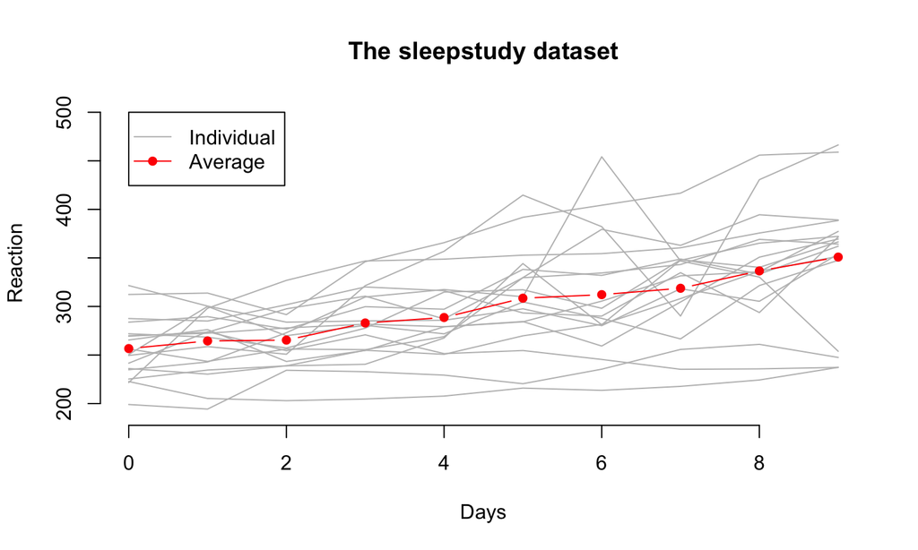

## Setting priors

## `get_prior()`

Given a model formula you can find the parameters to set priors for via (below are the defaults used by brms):

```r
get_prior(Reaction ~ Days, data = sleepstudy, family = gaussian)
```

```
##                   prior     class coef group resp dpar nlpar bound
## 1                               b
## 2                               b Days
## 3 student_t(3, 289, 59) Intercept
## 4   student_t(3, 0, 59)     sigma
```

We'll start with a *complete pooling* model (not acknowledging the clustering in the data)

## `set_prior()`

```r
priors = c(set_prior("normal(500, 100)", class = "Intercept"),
           set_prior("normal(0, 50)", class = "b"), # fixed effect of 'Days'
           set_prior("cauchy(0, 50)", class = "sigma"))
```

or

```r
priors = set_prior("normal(500, 100)", class = "Intercept") +
           set_prior("normal(0, 50)", class = "b") +
           set_prior("cauchy(0, 50)", class = "sigma")
```

## `brm()` - sample from the prior distribution

```r
p1 = brm(Reaction ~ Days, data = sleepstudy,
         family = gaussian,
         prior = priors,
         sample_prior = "only")
```

## Prior Predictive Distribution

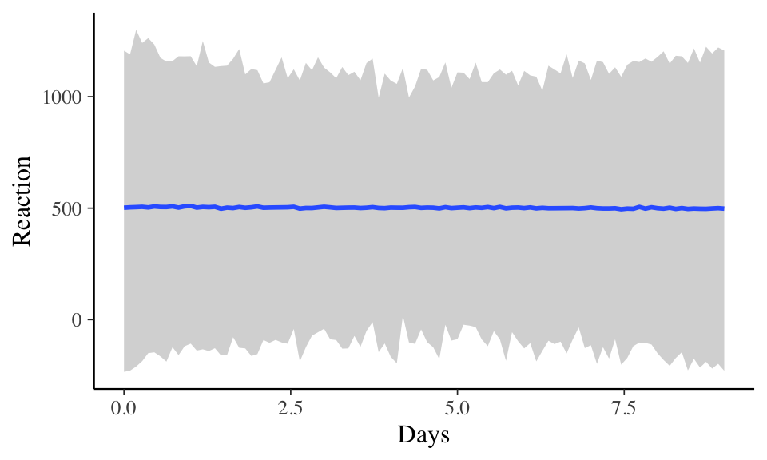

```r
marginal_effects(p1, method="predict")
```

- `marginal_effects()` can display the "fitted" regression line (or condition differences)
- or it can display marginal predictions, as done here for prior samples

## Prior Predictive Distribution

- The predictions of small (and negative!) reaction times are a little worrying
- We could specify truncation of the data (e.g., `Reaction | trunc(lb=0) ~ ...`)
- But this is ok for our purposes

## Fitting models

## `brm()` - fit model

```r
m1 = brm(Reaction ~ Days, data = sleepstudy,
         family = gaussian,
         prior = priors,
         save_all_pars = T)
```

## `brmsfit` object

```r
summary(m1)
```

```
##  Family: gaussian
##   Links: mu = identity; sigma = identity
## Formula: Reaction ~ Days
##    Data: sleepstudy (Number of observations: 180)
## Samples: 4 chains, each with iter = 2000; warmup = 1000; thin = 1;
##          total post-warmup samples = 4000
##
## Population-Level Effects:
##           Estimate Est.Error l-95% CI u-95% CI Eff.Sample Rhat
## Intercept   251.66      6.69   238.45   264.61       3723 1.00
## Days         10.45      1.25     8.05    12.97       3381 1.00
##
## Family Specific Parameters:
##       Estimate Est.Error l-95% CI u-95% CI Eff.Sample Rhat
## sigma    47.87      2.53    43.25    52.98       3818 1.00
##
## Samples were drawn using sampling(NUTS). For each parameter, Eff.Sample
## is a crude measure of effective sample size, and Rhat is the potential
## scale reduction factor on split chains (at convergence, Rhat = 1).
```

## `brmsfit` object

```r
fixef(m1) # fixed effects
```

```
##            Estimate Est.Error      Q2.5    Q97.5
## Intercept 251.65673  6.687789 238.44790 264.6095
## Days       10.45444  1.248855   8.04829  12.9705
```

```r
VarCorr(m1) # residual SD
```

```
## $residual__
## $residual__$sd
##  Estimate Est.Error     Q2.5    Q97.5
##  47.86982  2.532455 43.25237 52.97693
```

```r
rhat(m1) # R hat statistic (convergence)
```

```
##    b_Intercept         b_Days          sigma temp_Intercept           lp__
##      1.0001730      0.9999002      0.9993905      0.9999337      1.0011094
```

## `brmsfit` object

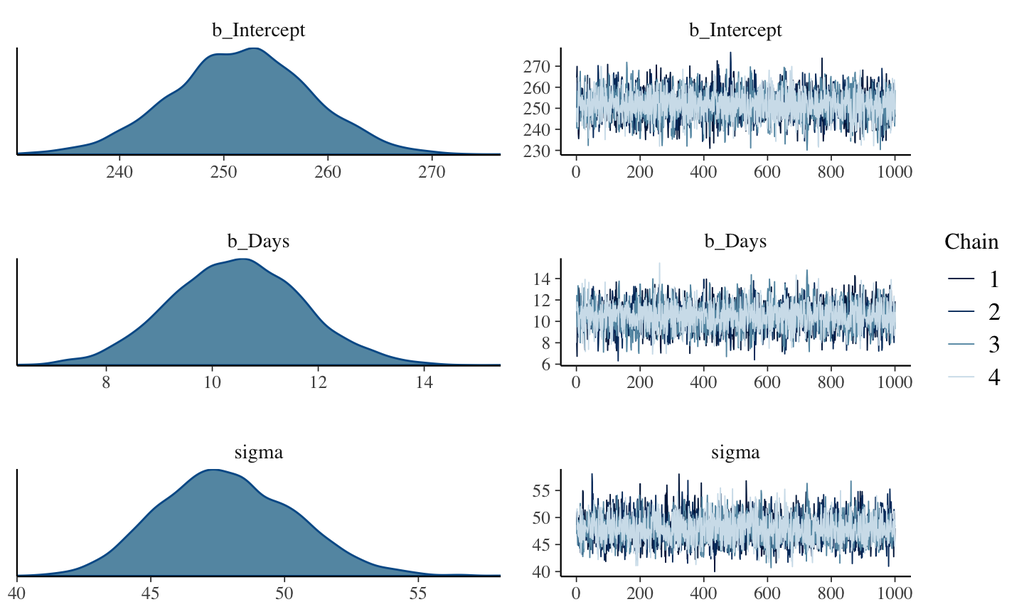

```r
plot(m1) # plot posterior samples
```

## Posterior predictive checks and marginal effects

## `pp_check`

Compare the distribution of the data with distributions generated from the model

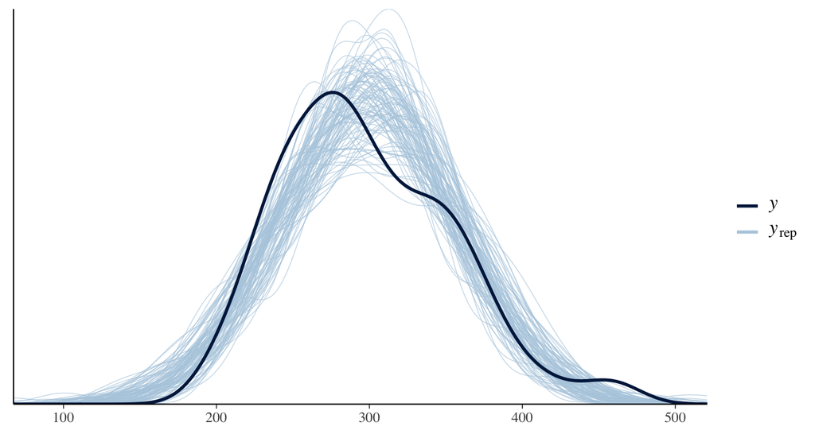

```r
pp_check(m1, nsamples = 100)
```

## The `bayesplot` package

- The [`bayesplot` package](https://mc-stan.org/bayesplot/) has lots of functions for plotting Bayesian models (see also `brms::stanplot` function)
- Particularly useful for posterior predictive checks
- To use, we need to generate predictive distributions (\(y_{rep}\))

## \(y_{rep}\) via `posterior_predict`

```r
yrep = posterior_predict(m1)

dim(yrep) # row for each step in chain, column for each observation
```

```
## [1] 4000  180
```

## `bayesplot::ppc_stat`

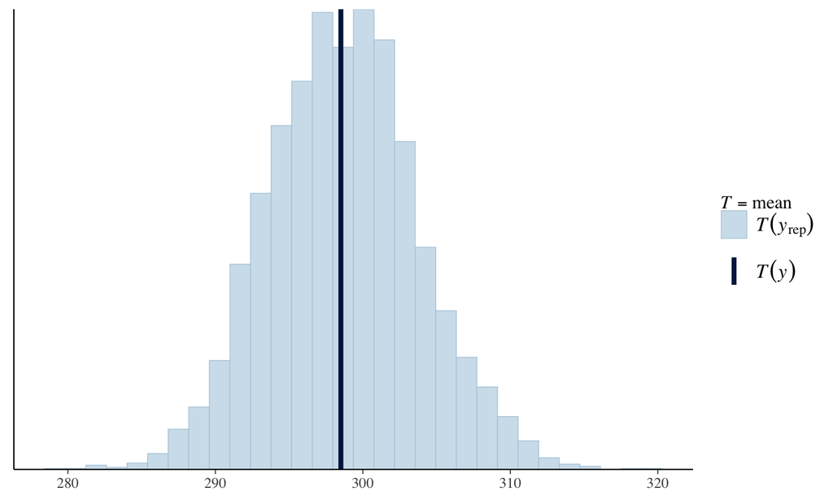

```r
ppc_stat(y = sleepstudy$Reaction, yrep = yrep) # stat = "mean" by default
```

## `bayesplot::ppc_stat`

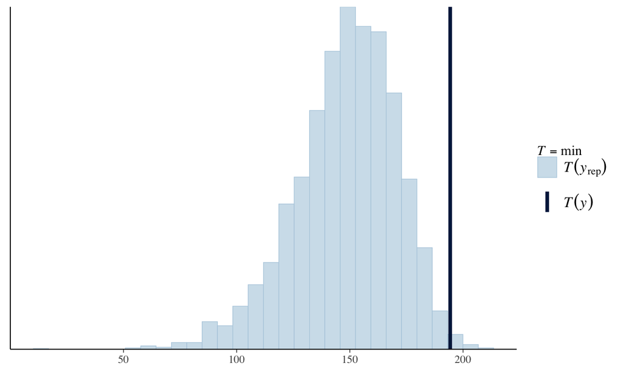

```r
ppc_stat(y = sleepstudy$Reaction, yrep = yrep, stat = "min")
```

## `bayesplot::ppc_stat_grouped`

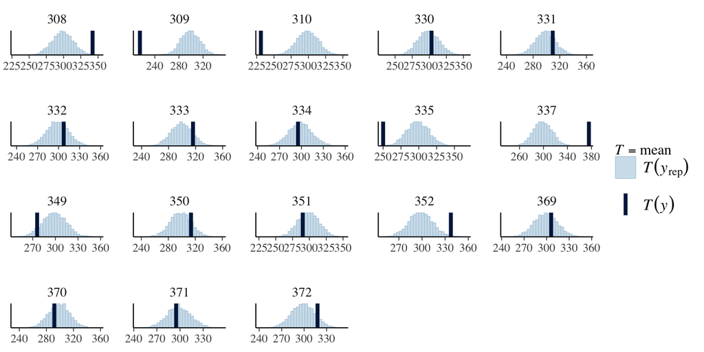

```r
ppc_stat_grouped(y = sleepstudy$Reaction, yrep = yrep,
                 group = sleepstudy$Subject)
```

## `marginal_effects`

We can plot the fitted regression line

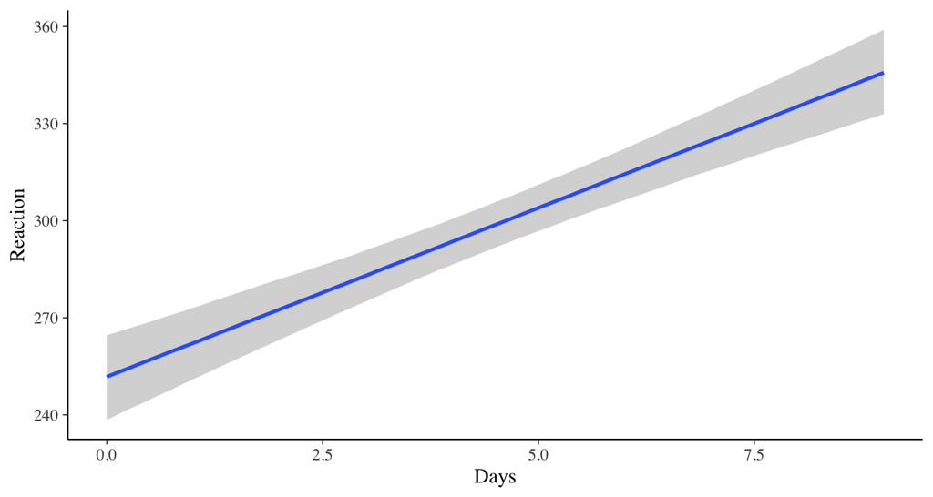

```r
marg_eff1 = marginal_effects(m1)
plot(marg_eff1)
```

## `marginal_effects`

`marginal_effects` also returns a data frame with median (estimate__) and 95% credible intervals (lower**, upper**) for different predictor values

```r
head(marg_eff1$Days)
```

```
##         Days Reaction cond__  effect1__ estimate__     se__  lower__
## 1 0.00000000 298.5079      1 0.00000000   251.7547 6.493655 238.4479
## 2 0.09090909 298.5079      1 0.09090909   252.7276 6.407890 239.6192
## 3 0.18181818 298.5079      1 0.18181818   253.6650 6.290718 240.8383
## 4 0.27272727 298.5079      1 0.27272727   254.6064 6.170887 241.9694
## 5 0.36363636 298.5079      1 0.36363636   255.5805 6.070109 243.0523
## 6 0.45454545 298.5079      1 0.45454545   256.5525 5.966611 244.1230
##    upper__
## 1 264.6095
## 2 265.3585
## 3 266.0935
## 4 266.8820
## 5 267.6001
## 6 268.3621
```

## Models with random effects

### Introducing partial pooling

## Model 2: random intercept

```r
# need to add a prior for the random participant effect
priors = c(priors,
           set_prior("cauchy(0, 100)", class = "sd")) # SD of random intercept

m2 = brm(Reaction ~ Days + (1 | Subject),
         data = sleepstudy, family = gaussian,
         prior=priors)
```

\[ y_i \sim \mbox{Normal}(\beta_0 + b_{j[i]} + \beta_1x_i, \; \sigma) \] \[ b_j \sim \mbox{Normal}(0, \sigma^{(b)}) \]

## summary (note: Group-Level Effects:)

```r
summary(m2)
```

```
##  Family: gaussian
##   Links: mu = identity; sigma = identity
## Formula: Reaction ~ Days + (1 | Subject)
##    Data: sleepstudy (Number of observations: 180)
## Samples: 4 chains, each with iter = 2000; warmup = 1000; thin = 1;
##          total post-warmup samples = 4000
##
## Group-Level Effects:
## ~Subject (Number of levels: 18)
##               Estimate Est.Error l-95% CI u-95% CI Eff.Sample Rhat
## sd(Intercept)    39.87      7.95    27.58    57.72        692 1.01
##
## Population-Level Effects:
##           Estimate Est.Error l-95% CI u-95% CI Eff.Sample Rhat
## Intercept   253.76     10.00   234.26   273.42        753 1.00
## Days         10.47      0.79     8.88    11.99       3941 1.00
##
## Family Specific Parameters:
##       Estimate Est.Error l-95% CI u-95% CI Eff.Sample Rhat
## sigma    31.18      1.73    28.06    34.84       2933 1.00
##
## Samples were drawn using sampling(NUTS). For each parameter, Eff.Sample
## is a crude measure of effective sample size, and Rhat is the potential
## scale reduction factor on split chains (at convergence, Rhat = 1).
```

## Model 2

```r
fixef(m2) # fixed effects
```

```
##            Estimate Est.Error       Q2.5     Q97.5
## Intercept 253.75548 9.9953637 234.264322 273.42493
## Days       10.47473 0.7874219   8.879992  11.99333
```

```r
VarCorr(m2) # Subject intercept and residual SDs
```

```
## $Subject
## $Subject$sd
##           Estimate Est.Error     Q2.5    Q97.5
## Intercept 39.87453  7.951218 27.58281 57.72386
##
##
## $residual__
## $residual__$sd
##  Estimate Est.Error     Q2.5    Q97.5
##  31.17695  1.728993 28.06413 34.83642
```

## more `marginal_effects`

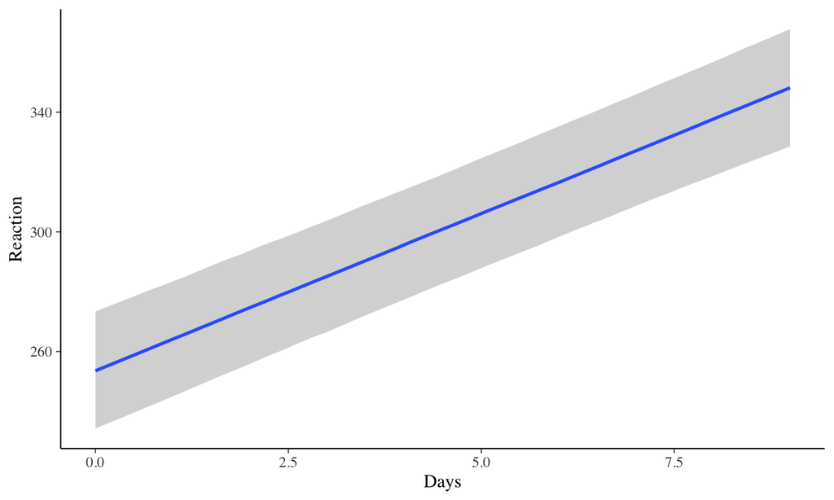

```r
marginal_effects(m2)
```

## more `marginal_effects`

Plot marginal effects for participants 1 to 6. `re_formula = NULL` includes random effects (`NA` excludes them, default)

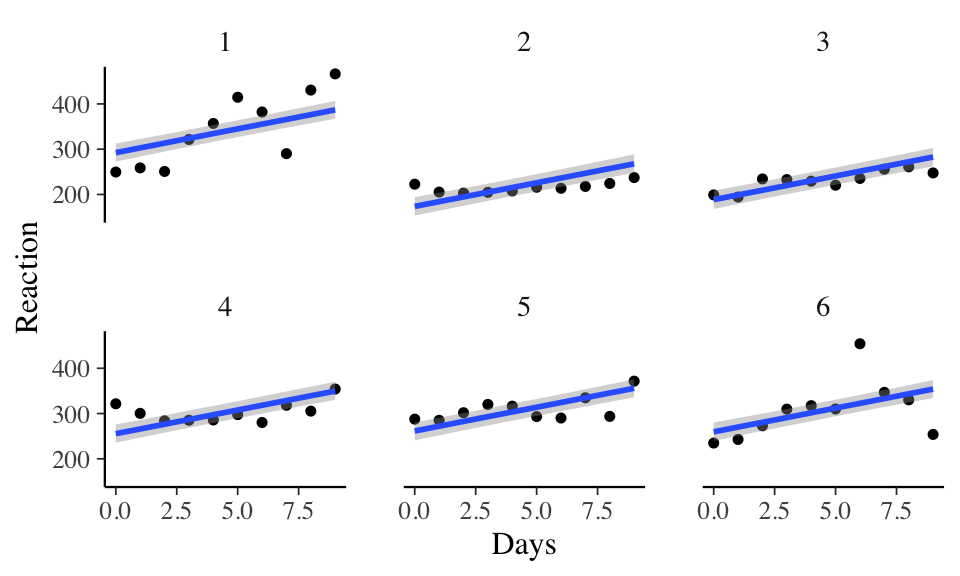

```r
plot(marginal_effects(m2,
                      conditions = data.frame(Subject=unique(sleepstudy$Subject)[1:6]),
                      re_formula = NULL), points=T)
```

## Plot random effects

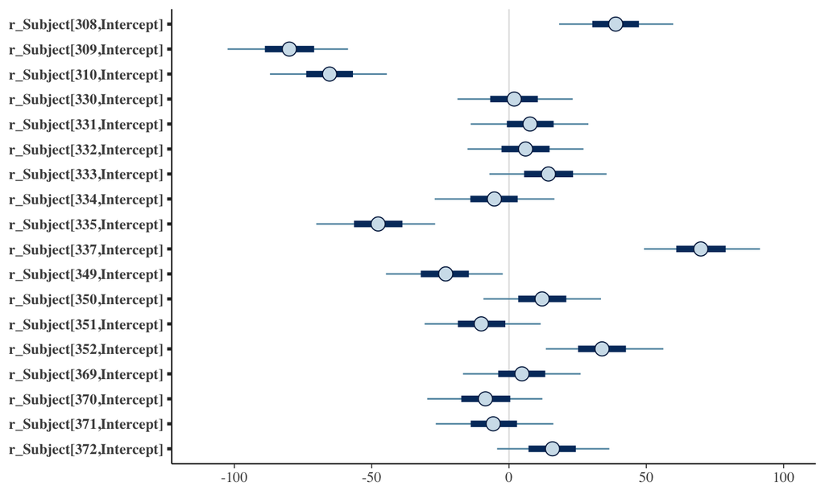

```r
stanplot(m2, pars = 'r_Subject') # see next slide on how to find pars
```

## `parnames`

If you don't know *all* the names of the parameters in your model…

```r
parnames(m2)
```

```
##  [1] "b_Intercept"              "b_Days"
##  [3] "sd_Subject__Intercept"    "sigma"
##  [5] "temp_Intercept"           "r_Subject[308,Intercept]"
##  [7] "r_Subject[309,Intercept]" "r_Subject[310,Intercept]"
##  [9] "r_Subject[330,Intercept]" "r_Subject[331,Intercept]"
## [11] "r_Subject[332,Intercept]" "r_Subject[333,Intercept]"
## [13] "r_Subject[334,Intercept]" "r_Subject[335,Intercept]"
## [15] "r_Subject[337,Intercept]" "r_Subject[349,Intercept]"
## [17] "r_Subject[350,Intercept]" "r_Subject[351,Intercept]"
## [19] "r_Subject[352,Intercept]" "r_Subject[369,Intercept]"
## [21] "r_Subject[370,Intercept]" "r_Subject[371,Intercept]"
## [23] "r_Subject[372,Intercept]" "lp__"
## [25] "z_1[1,1]"                 "z_1[1,2]"
## [27] "z_1[1,3]"                 "z_1[1,4]"
## [29] "z_1[1,5]"                 "z_1[1,6]"
## [31] "z_1[1,7]"                 "z_1[1,8]"
## [33] "z_1[1,9]"                 "z_1[1,10]"
## [35] "z_1[1,11]"                "z_1[1,12]"
## [37] "z_1[1,13]"                "z_1[1,14]"
## [39] "z_1[1,15]"                "z_1[1,16]"
## [41] "z_1[1,17]"                "z_1[1,18]"
```

## m3: random intercept + slope

```r
priors = c(priors,
           set_prior("lkj(1)", class = "cor")) # uniform prior on correlation

m3 = brm(Reaction ~ Days + (1 + Days | Subject),
         data = sleepstudy, family = gaussian,
         prior=priors)
```

\[ y_i \sim \mbox{Normal}(\beta_0 + b_{0j[i]} + (\beta_1 + b_{1j[i]})x_i, \; \sigma) \]

\[ \begin{pmatrix} b_{0j} \\ b_{1j} \end{pmatrix} \sim MVN\left(\begin{pmatrix} 0 \\ 0 \end{pmatrix}, \; \Sigma \right). \]

See [here](https://mc-stan.org/docs/2_18/stan-users-guide/multivariate-hierarchical-priors-section.html) for more detail on multivariate priors

## Model 3: random intercept + slope

```r
summary(m3)
```

```
##  Family: gaussian
##   Links: mu = identity; sigma = identity
## Formula: Reaction ~ Days + (1 + Days | Subject)
##    Data: sleepstudy (Number of observations: 180)
## Samples: 4 chains, each with iter = 2000; warmup = 1000; thin = 1;
##          total post-warmup samples = 4000
##
## Group-Level Effects:
## ~Subject (Number of levels: 18)
##                     Estimate Est.Error l-95% CI u-95% CI Eff.Sample Rhat
## sd(Intercept)          27.18      6.96    15.70    43.16       1664 1.00
## sd(Days)                6.64      1.57     4.17    10.32       1518 1.00
## cor(Intercept,Days)     0.07      0.29    -0.49     0.63       1157 1.00
##
## Population-Level Effects:
##           Estimate Est.Error l-95% CI u-95% CI Eff.Sample Rhat
## Intercept   252.10      7.65   236.37   267.89       1391 1.00
## Days         10.73      1.73     7.41    14.34       1314 1.00
##
## Family Specific Parameters:
##       Estimate Est.Error l-95% CI u-95% CI Eff.Sample Rhat
## sigma    25.86      1.54    23.04    29.15       3142 1.00
##
## Samples were drawn using sampling(NUTS). For each parameter, Eff.Sample
## is a crude measure of effective sample size, and Rhat is the potential
## scale reduction factor on split chains (at convergence, Rhat = 1).
```

## Model 3: random intercept + slope

```r
VarCorr(m3)$Subject$sd # random effects SDs
```

```
##            Estimate Est.Error      Q2.5    Q97.5
## Intercept 27.183292  6.963350 15.697611 43.16141
## Days       6.639577  1.567464  4.173964 10.31706
```

```r
VarCorr(m3)$Subject$cor # random effects correlation
```

```
## , , Intercept
##
##            Estimate Est.Error       Q2.5     Q97.5
## Intercept 1.0000000 0.0000000  1.0000000 1.0000000
## Days      0.0688427 0.2921568 -0.4944926 0.6289119
##
## , , Days
##
##            Estimate Est.Error       Q2.5     Q97.5
## Intercept 0.0688427 0.2921568 -0.4944926 0.6289119
## Days      1.0000000 0.0000000  1.0000000 1.0000000
```

## Model 3: random intercept + slope

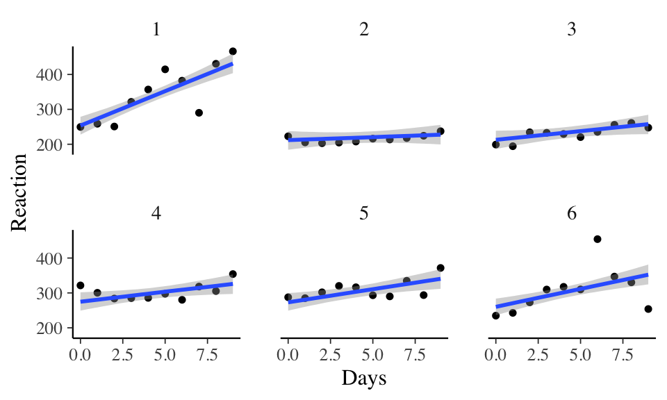

```r
plot(marginal_effects(m3,
                      conditions = data.frame(Subject=unique(sleepstudy$Subject)[1:6]),
                      re_formula = NULL), points=T)
```

## Comparing models

## `add_criterion`

- Add model fit criteria to the model objects
- Can add
  - approximate loo (via psis)
  - waic
  - k-fold cross validation
  - \(R^2\) (more [here](https://www.tandfonline.com/doi/abs/10.1080/00031305.2018.1549100))
  - marginal likelihood (via bridge sampling)

## `add_criterion`

```r
m1 = add_criterion(m1, c("loo", "waic", "marglik"))
m2 = add_criterion(m2, c("loo", "waic", "marglik"))
m3 = add_criterion(m3, c("loo", "waic", "marglik"))
```

```r
m1$loo
```

```
##
## Computed from 4000 by 180 log-likelihood matrix
##
##          Estimate   SE
## elpd_loo   -953.3 10.5
## p_loo         3.2  0.5
## looic      1906.6 21.1
## ------
## Monte Carlo SE of elpd_loo is 0.0.
##
## All Pareto k estimates are good (k < 0.5).
## See help('pareto-k-diagnostic') for details.
```

## `loo_compare`

```r
m1 = add_criterion(m1, c("loo", "waic", "marglik"))
m2 = add_criterion(m2, c("loo", "waic", "marglik"))
m3 = add_criterion(m3, c("loo", "waic", "marglik"))
```

```r
loo_compare(m1, m2, m3) # or loo_compare(m1,m2,m3,criterion="waic")
```

```
##    elpd_diff se_diff
## m3   0.0       0.0
## m2 -23.0      12.1
## m1 -91.5      21.5
```

- `abs(elpd_diff)` > 2*`se_diff` favors top model (more on loo [here](https://cran.r-project.org/web/packages/loo/vignettes/loo2-example.html#comparing-the-models-on-expected-log-predictive-density))

## Bayes factors

- The `marglik` criterion is calculated by the [`bridgesampling` package](https://cran.r-project.org/web/packages/bridgesampling/index.html)
- The functions are loaded by `brms`
- To calculate `marglik` the argument `save_all_pars = T` must be set in `brm()`

## Bayes factors

```r
bayes_factor(m2, m1)
```

```
## The estimated Bayes factor in favor of x1 over x2 is equal to: 1.688973e+22
```

```r
bayes_factor(m3, m2)
```

```
## The estimated Bayes factor in favor of x1 over x2 is equal to: 15432890
```

```r
post_prob(m1, m2, m3, prior_prob = c(1/3, 1/3, 1/3))
```

```
##           m1           m2           m3
## 3.836454e-30 6.479668e-08 9.999999e-01
```

\[ \frac{p(M_1 \mid y)}{p(M_2 \mid y)} = B_{1,2} \times \frac{p(M_1)}{p(M_2)} \]

## To calculate each criterion separately

- `loo()`
- `waic()`
- `kfold()`
- `bayes_R2()`
- `bridge_sampler()`

## Do things with posterior samples

## `hypothesis`

- Savage-Dickey density ratio (requires `sample_prior = T or "yes"` in `brm()`)

```r
(m3_sav = hypothesis(x = m3, hypothesis = "Days = 0"))
```

```
## Hypothesis Tests for class b:
##   Hypothesis Estimate Est.Error CI.Lower CI.Upper Evid.Ratio Post.Prob
## 1 (Days) = 0    10.73      1.73     7.41    14.34          0         0
##   Star
## 1    *
## ---
## 'CI': 90%-CI for one-sided and 95%-CI for two-sided hypotheses.
## '*': For one-sided hypotheses, the posterior probability exceeds 95%;
## for two-sided hypotheses, the value tested against lies outside the 95%-CI.
## Posterior probabilities of point hypotheses assume equal prior probabilities.
```

## `hypothesis`

- The posterior doesn't overlap zero (which gives `Evid.Ratio = 0`)
- There are better examples in the other example scripts…

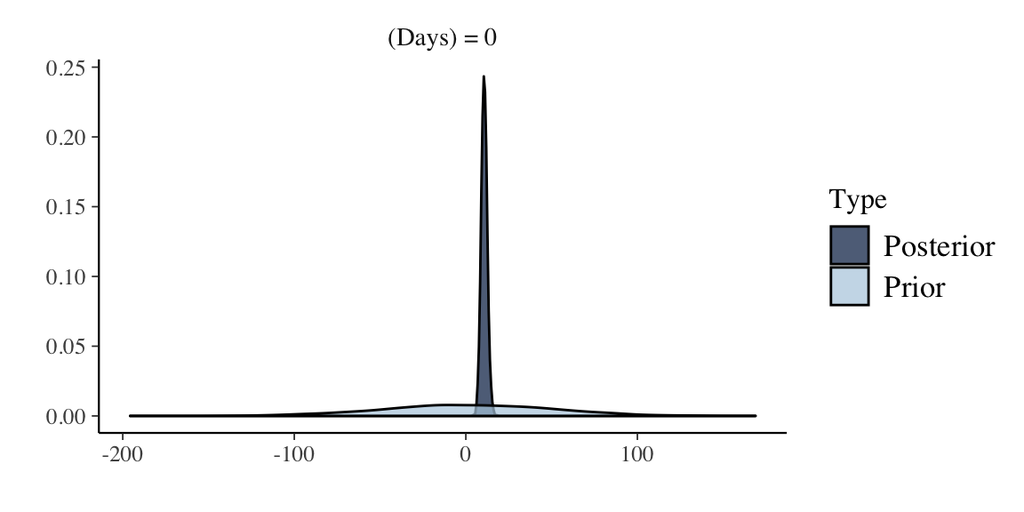

```r
plot(m3_sav)
```

## Extract samples - `posterior_samples`

```r
m3_days = posterior_samples(m3, pars = "b_Days")[,1]
```

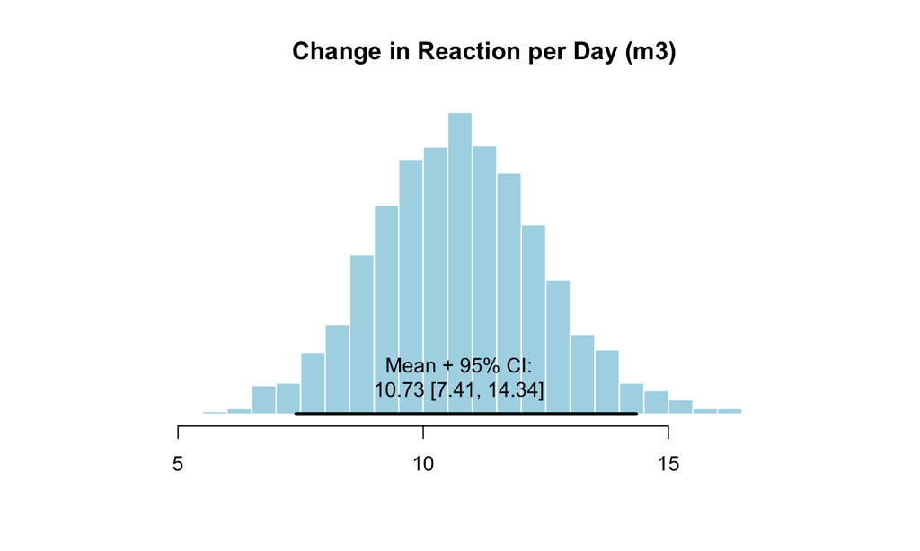

## Use samples to make predictions - `posterior_linpred`

- Alternative to `marginal_effects` (and more flexible)
- Below we make predictions for a new person (a new level of 'Subject')
- Predictions are for *expected value* (i.e., 'regression line'; use `posterior_predict` to include residual variance)

```r
newdat = data.frame(Days = 0:9, Subject=100)
m3_newp_pp = posterior_linpred(m3, # the fitted() function could also work
                               re_formula = NULL, # default, include random effects
                               newdata = newdat,
                               allow_new_levels=T)
```

## Use samples to make predictions

Each column represents a row in `newdat` (see previous slide)

```r
head(m3_newp_pp)
```

```
##          [,1]     [,2]     [,3]     [,4]     [,5]     [,6]     [,7]
## [1,] 286.6972 299.8187 312.9401 326.0616 339.1831 352.3045 365.4260
## [2,] 233.6314 244.1883 254.7452 265.3021 275.8590 286.4159 296.9728
## [3,] 236.7690 243.2955 249.8220 256.3486 262.8751 269.4016 275.9281
## [4,] 273.9887 286.2074 298.4260 310.6447 322.8633 335.0820 347.3006
## [5,] 277.7471 282.9380 288.1289 293.3198 298.5107 303.7016 308.8925
## [6,] 251.1197 268.7240 286.3282 303.9324 321.5366 339.1408 356.7450
##          [,8]     [,9]    [,10]
## [1,] 378.5475 391.6689 404.7904
## [2,] 307.5297 318.0866 328.6435
## [3,] 282.4547 288.9812 295.5077
## [4,] 359.5193 371.7379 383.9566
## [5,] 314.0834 319.2742 324.4651
## [6,] 374.3492 391.9534 409.5576
```

## Use samples to make predictions

Predictions for a new 'Subject' (based on 1000 samples from the posterior)

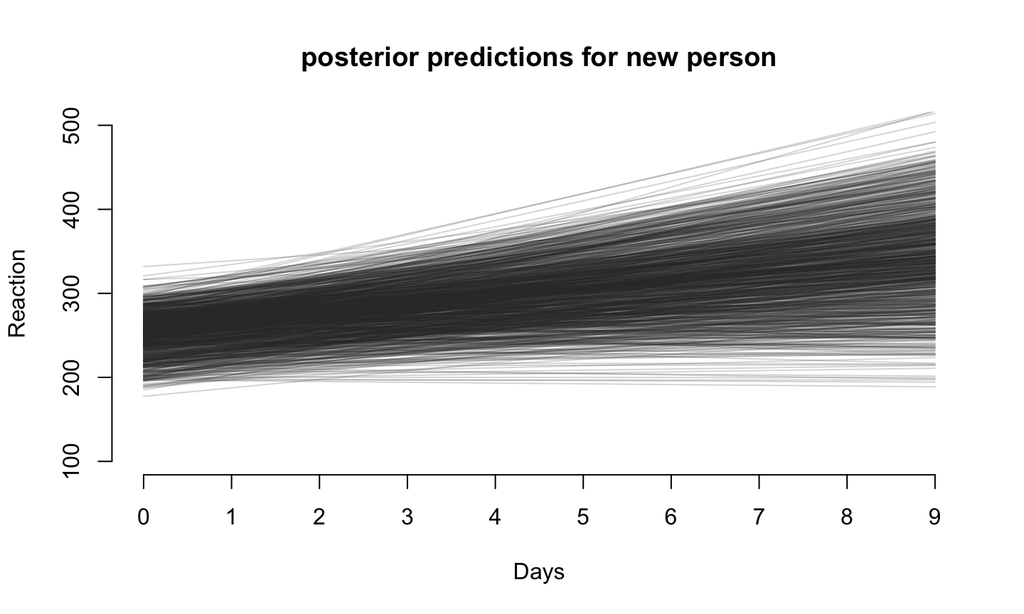

## Use samples to make predictions

Below we make predictions for the population

```r
newdat = data.frame(Days = 0:9)
m3_mean_pp = posterior_linpred(m3,
                               newdata = newdat,
                               re_formula = NA) # exclude random effects
```

## Use samples to make predictions

Predictions for the population (based on 1000 samples from the posterior)

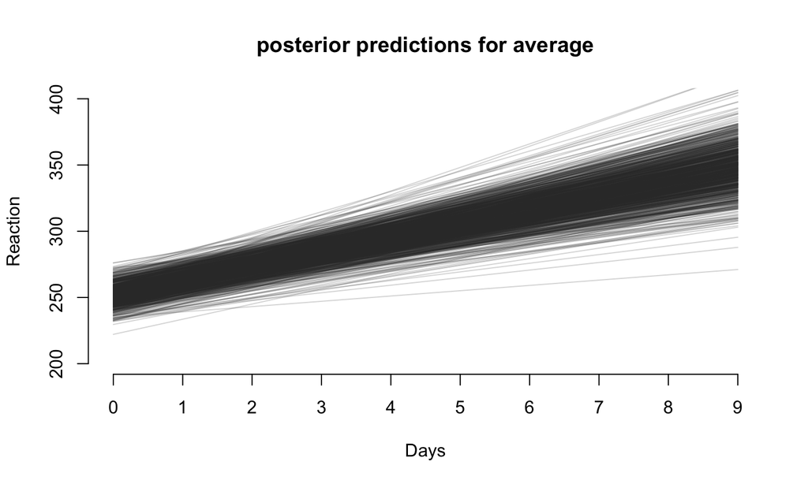

## Use samples to make predictions

Mean and 95% CI (red points are observed means)

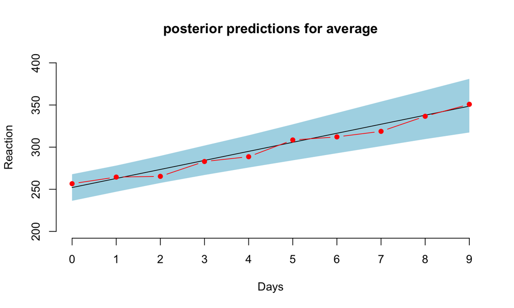

## Warning messages

## Divergent transitions

```r
1: There were 15 divergent transitions after warmup. Increasing adapt_delta above 0.8 may help.
2: Examine the pairs() plot to diagnose sampling problems
```

Could be:

- The steps taken are too big; in which case, increase `adapt_delta`
- The model needs to be reparameterized (in which case the above will not help. More [here](https://mc-stan.org/docs/2_18/stan-users-guide/reparameterization-section.html))

## Divergent transitions

```r
1: There were X divergent transitions after warmup.
Increasing adapt_delta above 0.8 may help.
2: Examine the pairs() plot to diagnose sampling problems
```

- `adapt_delta` controls the size of sampling steps, increasing leads to smaller steps
- To increase, add `control = list(adapt_delta = 0.95))` (or another value > .8) to the `brm()` call

## Maximum treedepth exceeded

```r
## Warning: There were X transitions after warmup that exceeded the maximum treedepth.
Increase max_treedepth above 10.
See ## http://mc-stan.org/misc/warnings.html#maximum-treedepth-exceeded
```

- The No-U Turn Sampler is being stopped too early (to avoid long run time)
- Can be increased via `control = list(max_treedepth = 15))` (or another value > 10)
- Sometimes also indicates that model should be reparameterized (see [here](https://mc-stan.org/docs/2_18/reference-manual/hmc-algorithm-parameters.html))

## Convergence Failure

```r
## Warning: The model has not converged (some Rhats are > 1.1).
Do not analyse the results!
## We recommend running more iterations and/or setting stronger priors.
```

For all possible warnings see: [Brief guide to Stan's warnings](https://mc-stan.org/misc/warnings.html#compiler-warnings)

## Examples

## brms-example1.R

- This analysis has been covered in these slides
- Contains some possible extensions to the models we fit at the end
- *Note:* I usually wouldn't throw all of these methods (i.e., bridge sampling, Bayes factors, loo, waic, Savage-Dickey, ROPE, CI, HDI) at one problem. This is just to demonstrate the range of `brms`
- The approach you use will be determined by your goals/ interests (e.g., estimation vs. model comparison vs. null testing)

## brms-example2.R

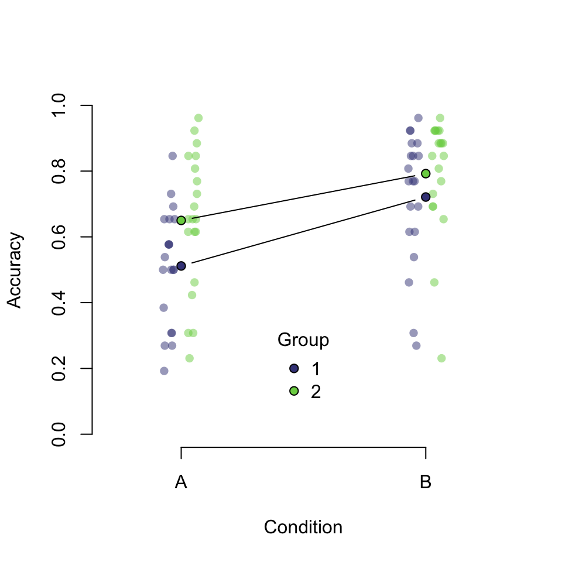

- Hypothetical data from a memory experiment
- Recall accuracy for two groups under two conditions
- The same items appear in both conditions
- `bernoulli(link = "logit")`

## brms-example3.R

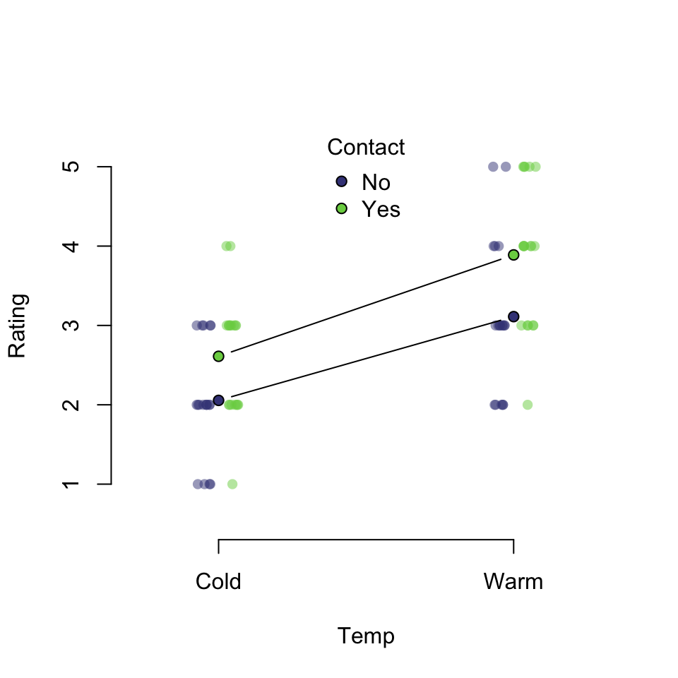

- Uses the [`wine` dataset](https://rdrr.io/rforge/ordinal/man/wine.html) from the `ordinal` package
- Temperature and whether there was contact between juice and skin during production
- Rating of bitterness
- `cumulative(link = "probit")`

## brms-example3.R

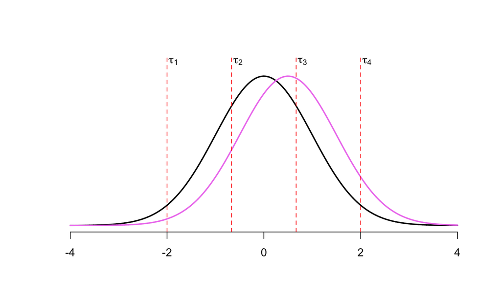

More about the cumulative model [here](https://journals.sagepub.com/doi/abs/10.1177/2515245918823199)

## More model families

## `family`

This workshop covers `gaussian`, `bernoulli/binomial`, and `cumulative` families as they will probably be most used by psychologists. Others that might be useful:

- `von_mises` for circular data
- `multinomial` for multiple categorical outcomes
- `lognormal` for positively skewed distributions (many options)

See `?brmsfamily` for a full range

## Additional functionality

### stuff we didn't cover but might be useful to you

## Including known standard errors

`brms` allows to include standard errors for meta-analyses

```r
fit1 <- brm(y | se(sey) ~ x, data = dat)
```

Alternatively, you can do weighted regression

```r
fit1 <- brm(y | weights(wy) ~ x, data = dat)
```

See details in `?brmsformula` for more

## Censored and truncated data

For censored data, you need to specify type of censoring (left, right, interval) and the bound for interval censoring (see `?brmsformula`)

```r
fit1 <- brm(y | cens(censored) ~ x, data = dat)
```

If the outcome has a truncated range, this can be specified:

```r
fit1 <- brm(y | trunc(lb = 0, ub = 100) ~ x, data = dat)
```

## Monotonic effects

From brms-example1.R

- For an ordinal predictor we can treat it as a monotonic predictor where differences between adjacent levels are not assumed to be equal
- Instead `mo()` allows you to model the effect of the predictor as monotonically increasing or decreasing (but not linear)
- see `vignette("brms_monotonic")` for more

```r
m4 = brm(Reaction ~ mo(Days) + (1 + mo(Days) | Subject), data = sleepstudy,
         family = gaussian,
         prior=priors
```

## Smooth terms

It is possible to use functions from the [`mgcv` package](https://cran.r-project.org/web/packages/mgcv/index.html) to implement generalized additive models

```r
fit1 <- brm(y ~ s(x), data = dat)
```

See this [blog](https://www.fromthebottomoftheheap.net/2018/04/21/fitting-gams-with-brms/) for more detail

## Distributional regression

From brms-example1.R

- `brms` allows you to model other parameters of the response distribution
- In this case, `sigma` (residual variance) is allowed to vary with Days of sleep deprivation

```r
m5_form = bf(Reaction ~ Days + (1 + Days | Subject),
             sigma ~ Days)

priors = priors +
         set_prior("cauchy(0, 50)", class = "b", dpar = "sigma")

m5 = brm(m5_form, data = sleepstudy,
         family = gaussian,
         prior=priors)
```

## Useful Links

- https://cran.r-project.org/web/packages/brms/vignettes/ (includes articles on using `brms`)
- [Signal detection theory](https://vuorre.netlify.com/post/2017/10/09/bayesian-estimation-of-signal-detection-theory-models-part-1/)
- [Ordinal models](https://journals.sagepub.com/doi/abs/10.1177/2515245918823199)
- [Monotonic effects](https://psyarxiv.com/9qkhj/)
- [Bayes factors](https://rpubs.com/lindeloev/bayes_factors)